# Tonsil B cell scRNA-seq

Slingshot

Diego A. Espinoza

Last compiled on 22 January 2023

```r
require(magrittr)
require(knitr)
require(dplyr)
require(tidyr)
require(tibble)
require(ggplot2)
require(Seurat)
require(cowplot)
require(kableExtra)
require(readr)
require(readxl)
require(slingshot)
require(SingleCellExperiment)
require(mgcv)
require(slingshot)
require(tradeSeq)
require(patchwork)
require(pochi)
rerun_analysis <- FALSE
parent.directory <- "intermediate/"

cluster_heatmap <- function(my_data_frame, clusters = 3, max_zed = 3, plot_rownames = FALSE, color_brewer = "Set1", label_features = NULL, y_text_size = 10, get_clusters = FALSE, dist_method = "euclidean"){
    my_data_frame <- as.data.frame(t(scale(t(my_data_frame))))
    my_data_frame[my_data_frame > max_zed] <- max_zed
    my_data_frame[my_data_frame < -max_zed] <- -max_zed
    hclust_results <- hclust(dist(my_data_frame, method = dist_method))
    gene_order <- hclust_results$labels[hclust_results$order]
    cluster_results <- data.frame(cluster= cutree(hclust_results, k = clusters))
    cluster_results$cluster <- as.factor(cluster_results$cluster)
    cluster_results$gene <- rownames(cluster_results)
    cluster_results$gene <- factor(cluster_results$gene, levels = gene_order)
    if(get_clusters){
        return(cluster_results)
    }
    my_data_frame_long <- pivot_longer(my_data_frame %>% rownames_to_column(var = "gene"), -gene, values_to = "Z_sc", names_to = "pseudotime")
    my_data_frame_long$gene <- factor(my_data_frame_long$gene, levels = gene_order)
    my_data_frame_long$pseudotime <- factor(my_data_frame_long$pseudotime, levels = colnames(my_data_frame))
    my_labels <- ifelse(gene_order %in% label_features, gene_order, "")
    g_heatmap <- ggplot(my_data_frame_long, aes(x = pseudotime, y = gene, fill = Z_sc))+
        geom_tile()+
        scale_fill_viridis_c()+
        ylab(NULL)+
        scale_y_discrete(position = "right", expand = c(0.01, 0.01), labels = my_labels, breaks = my_labels)+
        theme(axis.text.x = element_blank(), axis.ticks.x = element_blank() , plot.margin = margin(l = 0), panel.background = element_rect(color = "white"), axis.text.y = element_text(size = y_text_size), legend.position = "bottom")
    g_dendro <- ggdendro::ggdendrogram(data = hclust_results)+
        scale_y_reverse(expand = c(0.01,0.01))+
        coord_flip()+
        theme(axis.text.y = element_blank(), axis.text.x = element_blank(), plot.margin = margin(r = 0))+scale_x_discrete(expand = c(0.01,0.01))
    g_clusters <- ggplot(cluster_results, aes(x = 1, y = gene, fill = cluster))+
        geom_tile()+
        scale_fill_manual(values = RColorBrewer::brewer.pal(clusters,color_brewer))+
        scale_y_discrete(position = "right", expand = c(0.01, 0.01), labels = NULL)+
        theme(axis.text.x = element_blank(), axis.ticks = element_blank() , plot.margin = margin(l = 0, r = 0), panel.background = element_rect(color = "white"), legend.position = "bottom")+
        ylab(NULL)+
        xlab("")
    (g_dendro | g_clusters | g_heatmap) + patchwork::plot_layout(widths = c(0.9,0.1,2), guides = "collect")&theme(legend.position = "bottom", legend.text = element_text(size = y_text_size * 0.75), legend.title = element_text(size = y_text_size * 0.75), legend.key.size = unit(0.2, "cm"))
}

gea_dotplot <- function(enrichment_results, p_adjust = 0.01, fill_color = "black"){
    temp_results <- enrichment_results@result
    temp_results %>%
        mutate(ID = gsub("HALLMARK_", "HM_", ID)) %>%
        mutate(ID = gsub("_", "\n", ID)) %>%
        separate(col = GeneRatio, sep = "/", into = c("Count", "Total")) %>%
        mutate(Count = as.numeric(Count), Total = as.numeric(Total)) %>%
        mutate(numeric_ratio = Count/Total) %>%
        arrange(numeric_ratio) %>%
        filter(p.adjust < p_adjust) %>%
        mutate(ID = factor(ID, levels = ID)) %>%
        ggplot(aes(x = numeric_ratio, y = ID, size = Count))+
        geom_point(color = fill_color)+
        theme_cowplot()+
        ylab(NULL)+
        xlab("Gene Ratio")
}


plot_gam_auc <- function(seurat_object, smoothed_values, chosen_feature, pseudotime_var = "pt_target_curve_trimmed", cluster_choice = "cluster_names", assay = "regulons"){
    smoothed_values_subset <- dplyr::filter(smoothed_values, geneset == chosen_feature)
    feature_val <- FetchData(seurat_object, vars = chosen_feature)
    temp_df <- FetchData(seurat_object, vars = c(pseudotime_var, cluster_choice))
    temp_df <- cbind(feature_val, temp_df)
    colnames(temp_df) <- c("feature_val", "pseudotime", "cluster")
    temp_df <- dplyr::filter(temp_df, !is.na(pseudotime))
    ggplot(temp_df, aes(x = pseudotime, y = feature_val, color = cluster))+
        geom_point()+
        geom_path(data = smoothed_values_subset, aes(x = impute_pseudotime, y = impute_auc, group = geneset), inherit.aes = FALSE, size = 2)+
        cowplot::theme_cowplot()
}
```

## A. Non-GC and Non-PC extraction

### A.1. Getting cell identifiers from large Seurat object

We get the original cluster names from the larger Seurat object so that we can extract the geneset and regulon AUC scores that were originally derived on the full dataset and now link them to the B.gcpc Seurat object.

Finally, we use slingshot’s pseudotemporal ordering along these curves to obtain a pseudotemporal axis that we can then use downstream to identify genes and gene sets that are perturbed along the pseudotemporal axis.

```r
load(paste0(parent.directory,"sct_seurat_gcpc_named_clusters.RData"))
load(paste0(parent.directory,"sct_reguloned.RData"))
B.subset <- B.combined[,colnames(B.gcpc)]
B.gcpc[["regulons"]] <- GetAssay(B.subset, assay = c("regulons"))
B.gcpc[["genesetAUC"]] <- GetAssay(B.subset, assay = c("genesetAUC"))
B.gcpc[["hmAUC"]] <- GetAssay(B.subset, assay = c("hmAUC"))
rm(B.combined, B.subset)

#get lineages and curves from slingshot
target_idents <- levels(Idents(B.gcpc))
target_idents <- target_idents[!(target_idents %in% c("GC IgA", "ASC IgM", "ASC IgG"))]
target_subset <- subset(B.gcpc, idents = target_idents)
cells_to_keep <- Embeddings(target_subset, "pca_UMAP") %>% as.data.frame %>% dplyr::filter(pcaumap_1 > -5) %>% rownames()
target_subset <- subset(target_subset, cells = cells_to_keep)

gcpc.lineages <- slingshot::getLineages(data = Embeddings(target_subset, "pca_UMAP"), clusterLabels = target_subset$cluster_names, start.clus = "GC 1", end.clus = c("GC LMO2", "LZ", "DZ 3"))
gcpc.curves <- slingshot::getCurves(gcpc.lineages, extend = "n")

#add pseudotime variables to Seurat object
curve_pseudotimes <- slingshot::slingPseudotime(gcpc.curves)
target_subset <- AddMetaData(target_subset, metadata =  curve_pseudotimes, col.name = paste0("pt_", colnames(curve_pseudotimes)))
B.gcpc <- AddMetaData(B.gcpc, metadata =  curve_pseudotimes, col.name = paste0("pt_", colnames(curve_pseudotimes)))

save(B.gcpc,
     target_subset,
     gcpc.curves,
     gcpc.lineages,
     file = paste0(parent.directory, "sct_slingshot_results.RData"))
```

### A.2 Visualizing tree and trajectories

Here we visualize the results of slingshot’s lineages, trajectories, and pseudotemporal ordering.

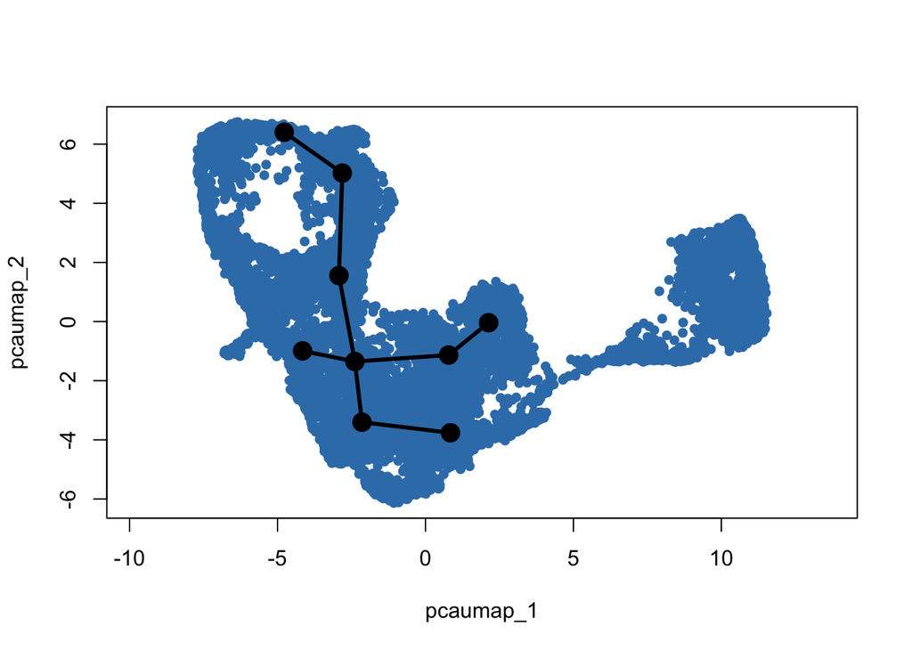

```r
load(file = paste0(parent.directory, "sct_slingshot_results.RData"))

gcpc.lineages.sds <- SlingshotDataSet(gcpc.lineages)
gcpc.curves.sds <- SlingshotDataSet(gcpc.curves)

set.seed(42)
plot(Embeddings(B.gcpc, "pca_UMAP"), col = RColorBrewer::brewer.pal(9,"Set1")[2], asp = 1, pch = 16)
lines(SlingshotDataSet(gcpc.lineages.sds), lwd = 3, col = 'black')
```

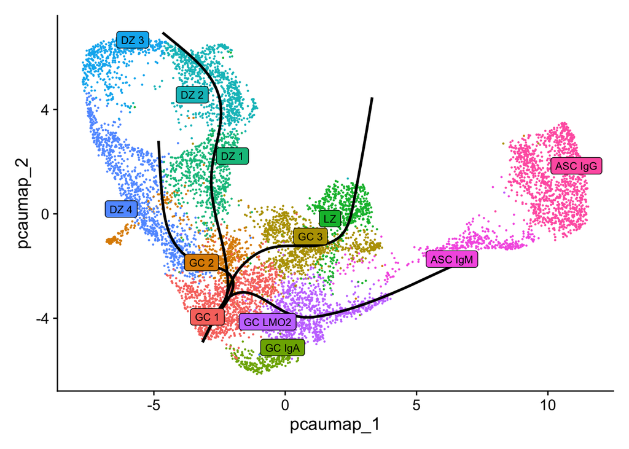

```r
base_dimplot <- DimPlot(B.gcpc, label = TRUE, label.box = TRUE, repel = TRUE, label.size = 3)+NoLegend()
num_curves <- length(gcpc.curves.sds@curves)
slingshot_path_mappings <- lapply(1:num_curves, function(i){
    curve_data <- as.data.frame(gcpc.curves.sds@curves[[i]]$s[gcpc.curves.sds@curves[[i]]$ord,])
    geom_path(data = curve_data, aes(x = pcaumap_1, y = pcaumap_2), inherit.aes = FALSE, color = "black", size = 1)
})
base_dimplot_paths <- base_dimplot
base_dimplot_paths$layers <- c(base_dimplot_paths$layers[[1]], slingshot_path_mappings, base_dimplot_paths$layers[[2]] )
base_dimplot_paths
```

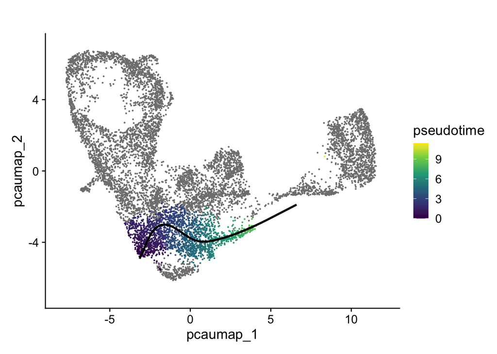

```r
target_curve <- "pt_Lineage4"
target_curve_index <- 4
B.gcpc$pt_target_curve <- ifelse(B.gcpc$cluster_names %in% c("GC LMO2", "GC 1"), B.gcpc@meta.data[,target_curve], NA)

pt_dimplot <- FeaturePlot(B.gcpc, features = "pt_target_curve")+scale_color_viridis_c("pseudotime")+slingshot_path_mappings[[target_curve_index]]+ggtitle("")
pt_dimplot
```

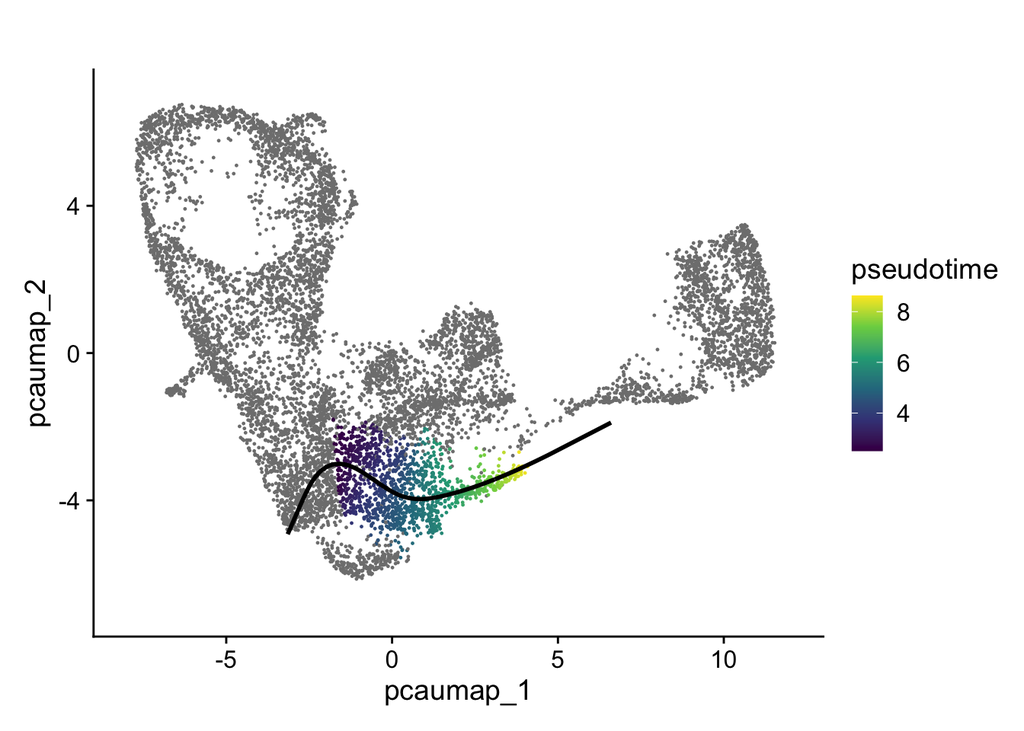

```r
pseudotime_cutoff_lo <- 2.5
B.gcpc$pt_target_curve_trimmed <- ifelse(B.gcpc$pt_target_curve > pseudotime_cutoff_lo, B.gcpc$pt_target_curve, NA)
pseudotime_cutoff_hi <- 10
B.gcpc$pt_target_curve_trimmed <- ifelse(B.gcpc$pt_target_curve_trimmed < pseudotime_cutoff_hi, B.gcpc$pt_target_curve_trimmed, NA)

pt_dimplot <- FeaturePlot(B.gcpc, features = "pt_target_curve_trimmed")+scale_color_viridis_c("pseudotime")+slingshot_path_mappings[[target_curve_index]]+ggtitle("")
pt_dimplot
```

### A.3 Pseudotemporal modeling

We next will extract the pseudotemporal axis for the GC LMO2 and GC 1 clusters, along with their gene-set (and regulon) AUCell scores. This is followed by running a 3-knot general additive model (GAM) using the `mgcv` R package along this axis for each regulon. We next use the derived GAMs to get “smoothed” expression values for each regulon across pseudotime.

```r
my_pt_1 <- B.gcpc@meta.data[,c("cluster_names", "pt_target_curve_trimmed")] %>%
    set_colnames(c("cluster", "t1")) %>%
    dplyr::filter((cluster == c("GC LMO2", "GC 1"))) %>%
    rownames_to_column(var = "cellID") %>%
    filter(!is.na(t1)) %>%
    dplyr::left_join(GetAssayData(B.gcpc, assay = "regulons") %>% t %>% as.data.frame %>% rownames_to_column(var = "cellID"), by = "cellID") %>%
    dplyr::arrange(t1)
my_pt_1_long <- pivot_longer(my_pt_1, -c(cellID, cluster, t1), values_to = "AUC", names_to = "geneset")

my_genesets_1 <- colnames(my_pt_1)[!(colnames(my_pt_1) %in% c("cellID", "cluster", "t1"))]

#run GAMs for each regulon
my_gams_1 <- lapply(1:length(my_genesets_1), function(i){
    temp_df <- my_pt_1[,c("t1", my_genesets_1[i])]
    if(sum(temp_df[,2]) == 0) return(NULL)
    colnames(temp_df)[2] <- "y"
    temp_model <- mgcv::gam(y ~ s(t1, k = 3), data=temp_df, method = "REML")
    return(temp_model)
})
names(my_gams_1) <- my_genesets_1
my_gams_1 <- my_gams_1[lengths(my_gams_1) > 0]

#format the GAM results as desired
my_gam_results_1 <- lapply(1:length(my_gams_1), function(i){
    geneset_name <- names(my_gams_1)[i]
    if(is.null(my_gams_1[[i]])) return(NULL)
    target_geneset <- names(my_gams_1)[[i]]
    x_new <- seq(min(my_pt_1$t1), max(my_pt_1$t1), length.out = 100)
    y_pred <- predict(my_gams_1[[i]], data.frame(t1 = x_new))
    largest_diff_real = diff(range(my_pt_1[,target_geneset]))
    largest_diff_pred = diff(range(y_pred))
    standardized_diff <- largest_diff_pred/mean(y_pred)
    y_var <- stats::var(y_pred)
    temp_model <- my_gams_1[[i]]
    p <- summary(temp_model)$s.table[,"p-value"]
    #anova_result <- anova.gam(temp_model)$s.table[,4]
    #anova.adj <- p.adjust(anova_result, method = "BH", n = length(my_genesets_1))
    data.frame(geneset = geneset_name, p_value = p, AUC_r_actual = largest_diff_real, AUC_r_pred = largest_diff_pred, mean_y = mean(y_pred), max_y = max(y_pred), var_y = y_var, sdiff_y = standardized_diff)
}) %>% do.call(rbind, .)

my_gam_results_1$p_adj <- p.adjust(my_gam_results_1$p_value, method = "BH", n = length(my_gam_results_1$p_value))

min_pt <- min(my_pt_1$t1)
max_pt <- max(my_pt_1$t1)
imputed_df_1 <- lapply(1:length(my_gams_1), function(i){
    x_new <- seq(min_pt, max_pt, length.out = 100)
    y_pred <- predict(my_gams_1[[i]], data.frame(t1 = x_new))
    if(length(y_pred) < 1){
        return(data.frame())
    }
    y_pred_scaled <- scale(y_pred)
    data.frame(geneset = names(my_gams_1)[i],
               impute_pseudotime = x_new,
               impute_auc = y_pred,
               impute_auc_scale = y_pred_scaled)
}) %>% do.call(rbind, .)

#assoc_gam_1 <- tradeSeq::associationTest(my_gams_1)
#svend_gam_1 <- tradeSeq::startVsEndTest(my_gams_1)
#p_value_choice_genesets <- 0.00001
## best_genesets_1 <- assoc_gam_1 %>%
#   tibble::rownames_to_column(var = "geneset") %>%
#   dplyr::filter(pvalue < p_value_choice_genesets) %>%
#   dplyr::pull(geneset)

p_value_choice_genesets <- 0.00001

my_gam_results_1 %>%
    dplyr::filter(p_adj < p_value_choice_genesets) %>%
    dplyr::arrange(AUC_r_pred) %>%
    dplyr::mutate(geneset = factor(geneset, levels = rev(geneset))) %>%
    dplyr::pull(geneset) %>% as.character() -> best_genesets_1

imputed_df_1_wide <- imputed_df_1 %>%
    dplyr::filter(geneset %in% best_genesets_1) %>%
    pivot_wider(id_cols = geneset,
                names_from = impute_pseudotime,
                values_from = impute_auc)  %>%
    column_to_rownames(var = "geneset")
colnames(imputed_df_1_wide) <- paste0("pt_", 1:ncol(imputed_df_1_wide))

save(B.gcpc,
     my_gams_1,
     my_gam_results_1,
     imputed_df_1,
     imputed_df_1_wide,
     best_genesets_1,
     my_pt_1,
     my_pt_1_long,
     file = paste0(parent.directory, "sct_slingshot_modeling_results.RData"))
```

## B. Data visualization

### B.1 slingshot visualization

```r
load(file = paste0(parent.directory, "sct_slingshot_modeling_results.RData"))
```

### B.2 Heatmap of scaled AUC values

Here, we choose the regulons that are “most significantly” differentially expressed along the pseudotemporal axis and plot their smoothed expression values across the pseudotemporal axis in the GC 1 to GC LMO2 principal curve.

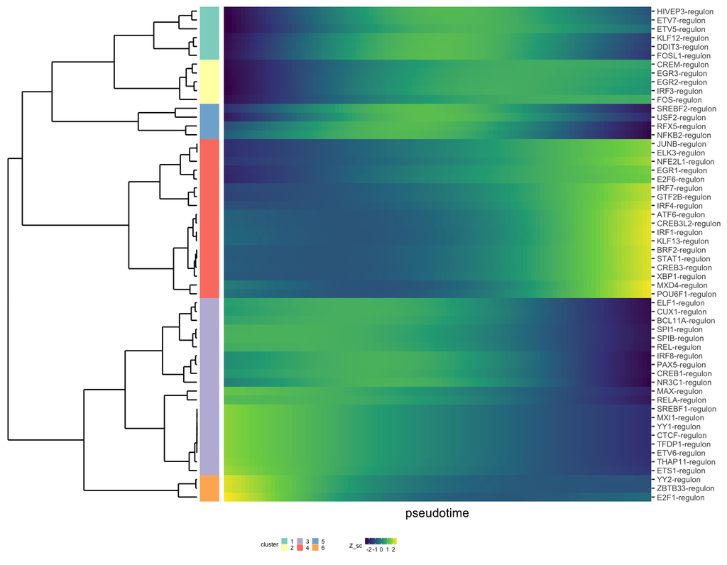

```r
chosen_metric <- "manhattan"
chosen_clusters <- 6

best_genesets_1_regulons <- grep("regulon", best_genesets_1, value = TRUE)

cluster_heatmap(imputed_df_1_wide[best_genesets_1_regulons,], max_zed = 3, clusters = chosen_clusters, label_features = rownames(imputed_df_1_wide), y_text_size = 7, color_brewer = "Set3", dist_method = chosen_metric)
```

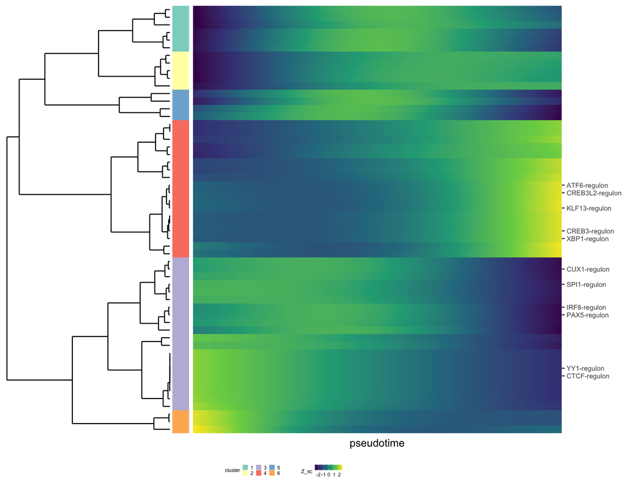

```r
chosen_features <- c("IRF8-regulon", "PAX5-regulon", "XBP1-regulon", "CREB3-regulon", "CREB3L2-regulon", "ATF6-regulon", "KLF13-regulon", "CUX1-regulon", "SPI1-regulon", "YY1-regulon", "CTCF-regulon")

cluster_heatmap(imputed_df_1_wide[best_genesets_1_regulons,], max_zed = 3, clusters = chosen_clusters, label_features = chosen_features, y_text_size = 7, color_brewer = "Set3", dist_method = chosen_metric)
```

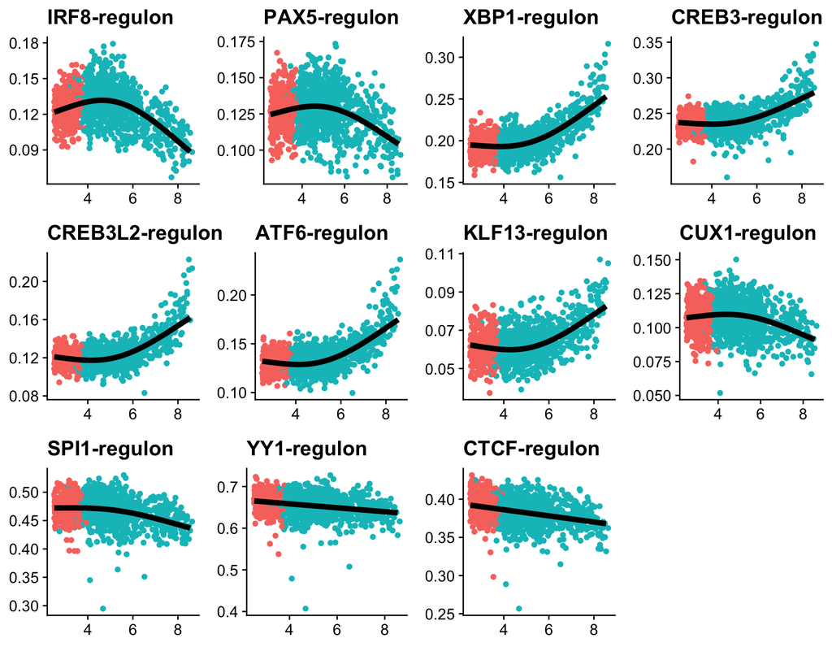

```r
quick_multi <- lapply(seq_along(chosen_features), function(i){
    plot_gam_auc(B.gcpc, imputed_df_1, chosen_feature = chosen_features[i])+ggtitle(chosen_features[i])+NoLegend()+xlab(NULL)+ylab(NULL)
}) %>% cowplot::plot_grid(plotlist = ., ncol = 4)
quick_multi
```

### B.3 Gene by gene tradeSeq

We also utilize the `tradeSeq` package to fit a GAM with 3 knots for each of the individual RNAs across the same pseudotemporal axis. `tradeSeq` allows us to choose particular tests (associationTest and startVsEndTest) to identify different patterns across the pseudotemporal axis.

```r
target_cells <- my_pt_1$cellID
count_matrix <- target_subset[["RNA"]]@counts[,target_cells]
curve_pseudotimes <- data.frame(target_curve = my_pt_1$t1, row.names = my_pt_1$cellID)
cell_weights <- data.frame(target_curve = rep(1, length(my_pt_1$cellID)), row.names = my_pt_1$cellID)
target_genes <- rownames(count_matrix[rowSums(count_matrix) > 5,])
B_sce <- fitGAM(counts = count_matrix, pseudotime = curve_pseudotimes, cellWeights = cell_weights, verbose = TRUE, nknots = 3, genes = target_genes)

assoRes <- associationTest(B_sce, lineages = FALSE)
#startRes <- startVsEndTest(B_sce, lineages = FALSE)

assoRes <- assoRes %>% rownames_to_column(var = "gene")
#startRes <- startRes %>% rownames_to_column(var = "gene")

save(B_sce, assoRes, target_genes, curve_pseudotimes, cell_weights, file = paste0(parent.directory, "sct_slingshot_gene_results.RData"))
```

### B.3 Cluster visualization by cluster

Here we can visualize the genes that are most associated with changes (based on the association test in `tradeSeq`) across the pseudotemporal axis.

```r
load(file = paste0(parent.directory, "sct_slingshot_gene_results.RData"))

pt_associated_results <- assoRes %>% dplyr::filter(pvalue < 0.0001)

predicted_smoothers <- lapply(1:length(pt_associated_results$gene), function(i){
    predict_gene <- pt_associated_results[i,"gene"]
    ysmooth <- tradeSeq::predictSmooth(models = B_sce, gene = predict_gene, nPoints = 40)
    return(ysmooth)
}) %>% do.call(rbind, .)

predicted_smoothers_wide <- predicted_smoothers %>%
    pivot_wider(id_cols = gene, names_from = time,values_from = yhat) %>%
    column_to_rownames(var = "gene")
colnames(predicted_smoothers_wide) <- paste0("pt_", 1:ncol(predicted_smoothers_wide))

num_clusters <- 6
gene_heatmap <- cluster_heatmap(predicted_smoothers_wide[,], max_zed = 2, clusters = num_clusters, label_features = c("IGHG3", "IGHM", "MZB1", "IRF8", "PAX5", "PRDM1", "LTB", "RGS13", "JCHAIN", "LMO2", "SSR4"), color_brewer = "Set1", y_text_size = 7, dist_method = "manhattan")
cluster_palette <- data.frame(cluster = 1:num_clusters, colors = RColorBrewer::brewer.pal(num_clusters, "Set1"))
gene_heatmap
```

[output not shown]